# A Global Fight for Access to Sanitation in School | UNICEF

Author

Soukaina Belabbes

Published

April 15, 2026

# **NO SANITATION = NO EDUCATION**

Globally, **600 million children** do not have a *basic sanitation service* at school. Where **1 in 5** primary schools have *no sanitation service* and **1 in 4** primary schools there is *no water service*. It’s a **silent crisis**: one that keeps millions of children away from classrooms every single day.

```python
# ══════════════════════════════════════════════════════════════════════
# Lance cette cellule EN PREMIER — une boîte va s'ouvrir
# Sélectionne les 3 fichiers CSV en même temps
# ══════════════════════════════════════════════════════════════════════

from google.colab import files
uploaded = files.upload()

print('Fichiers uploadés :')
for name in uploaded.keys():
    print(' ✅', name)
```

```
Saving unicef_metadata (2).csv to unicef_metadata (2) (2).csv
Saving unicef_indicator_2 (2).csv to unicef_indicator_2 (2) (2).csv
Saving unicef_indicator_1 (2).csv to unicef_indicator_1 (2) (2).csv
Fichiers uploadés :
 ✅ unicef_metadata (2) (2).csv
 ✅ unicef_indicator_2 (2) (2).csv
 ✅ unicef_indicator_1 (2) (2).csv
```

```python
import os
print(os.listdir('/content'))
```

```
['.config', 'unicef_indicator_1 (2) (1).csv', 'unicef_indicator_2 (2) (1).csv', 'unicef_indicator_2 (2) (2).csv', 'unicef_indicator_1 (2).csv', 'unicef_metadata (2).csv', 'unicef_indicator_1 (2) (2).csv', 'unicef_indicator_2 (2).csv', 'unicef_metadata (2) (2).csv', 'unicef_metadata (2) (1).csv', 'sa…
```

```python
import subprocess
subprocess.run(['pip', 'install', 'polars', 'plotnine', '-q'], check=True)

import polars as pl
import numpy as np
from plotnine import *
import warnings
warnings.filterwarnings('ignore')

indicator_1 = pl.read_csv('/content/unicef_indicator_1 (2) (1).csv')
indicator_2 = pl.read_csv('/content/unicef_indicator_2 (2).csv')
metadata    = pl.read_csv('/content/unicef_metadata (2).csv')

print('✅ Data loaded successfully!')
print(f'  Indicator 1 (child deprivation): {indicator_1.shape[0]} rows')
print(f'  Indicator 2 (school sanitation): {indicator_2.shape[0]} rows')
print(f'  Metadata (country level):        {metadata.shape[0]} rows')
```

```
✅ Data loaded successfully!
  Indicator 1 (child deprivation): 216 rows
  Indicator 2 (school sanitation): 2872 rows
  Metadata (country level):        13715 rows
```

```python
# We use our custom functions to keep the code clean and avoid repetition
# filter_total_sex() removes sex-disaggregated rows to avoid double counting
# get_most_recent() ensures we always use the latest available data per country

sanitation_recent = (
    filter_total_sex(indicator_2)
    .sort('time_period', descending=True)
    .group_by('country')
    .agg([
        pl.col('obs_value').first().alias('sanitation_pct'),
        pl.col('time_period').first().alias('year'),
        pl.col('alpha_3_code').first(),
    ])
)

deprivation_by_sex = (
    indicator_1
    .filter(pl.col('sex').is_in(['Female', 'Male']))
    .sort('time_period', descending=True)
    .group_by(['country', 'sex'])
    .agg(pl.col('obs_value').first().alias('deprivation_pct'))
)

meta_recent = (
    metadata
    .filter(pl.col('Life expectancy at birth, total (years)').is_not_null())
    .sort('year', descending=True)
    .group_by('country')
    .agg([
        pl.col('GDP per capita (constant 2015 US$)').first().alias('gdp_per_capita'),
        pl.col('Life expectancy at birth, total (years)').first().alias('life_expectancy'),
        pl.col('Population, total').first().alias('population'),
    ])
)

# Join all three datasets on country name
# Left join keeps all countries from sanitation even if metadata is missing
combined = (
    sanitation_recent
    .join(meta_recent, on='country', how='left')
    .filter(pl.col('sanitation_pct').is_not_null())
)

print(f"✅ Sanitation data: {sanitation_recent.shape[0]} countries")
print(f"✅ Deprivation data: {deprivation_by_sex.shape[0]} rows")
print(f"✅ Combined dataset: {combined.shape[0]} countries")

# Quick data quality check using our custom function
print(f"\n📊 Missing values check:")
print(f"  Life expectancy missing: {check_missing(combined, 'life_expectancy')}")
print(f"  GDP missing: {check_missing(combined, 'gdp_per_capita')}")
```

```
✅ Sanitation data: 165 countries
✅ Deprivation data: 144 rows
✅ Combined dataset: 165 countries

📊 Missing values check:
  Life expectancy missing: 6
  GDP missing: 12
```

```python
# ── Exploratory Data Analysis ──────────────────────────────────────────────────
# We explore the data before visualisation to understand its structure,
# check for missing values, and identify key patterns

print("=== INDICATOR 2 : School Sanitation Coverage ===")
print(f"Number of countries: {indicator_2['country'].n_unique()}")
print(f"Years covered: {indicator_2['time_period'].min()} to {indicator_2['time_period'].max()}")
print(f"Average sanitation coverage: {indicator_2['obs_value'].mean():.1f}%")
print(f"Min: {indicator_2['obs_value'].min():.1f}% | Max: {indicator_2['obs_value'].max():.1f}%")
print(f"Missing values: {indicator_2['obs_value'].is_null().sum()}")

print("\n=== INDICATOR 1 : Child Deprivation ===")
print(f"Number of countries: {indicator_1['country'].n_unique()}")
print(f"Average deprivation rate: {indicator_1['obs_value'].mean():.1f}%")
print(f"Missing values: {indicator_1['obs_value'].is_null().sum()}")

print("\n=== METADATA ===")
print(f"Number of countries: {metadata['country'].n_unique()}")
print(f"Years covered: {metadata['year'].min()} to {metadata['year'].max()}")
print(f"Missing life expectancy values: {metadata['Life expectancy at birth, total (years)'].is_null().sum()}")

print("\n=== COMBINED DATASET ===")
print(f"Final dataset: {combined.shape[0]} countries")
print(f"Countries with sanitation below 30%: {combined.filter(pl.col('sanitation_pct') < 30).shape[0]}")
print(f"Countries with sanitation above 90%: {combined.filter(pl.col('sanitation_pct') > 90).shape[0]}")
```

```
=== INDICATOR 2 : School Sanitation Coverage ===
Number of countries: 165
Years covered: 2000 to 2023
Average sanitation coverage: 81.4%
Min: 0.0% | Max: 100.0%
Missing values: 0

=== INDICATOR 1 : Child Deprivation ===
Number of countries: 72
Average deprivation rate: 8.8%
Missing values: 0

=== METADATA ===
Number of countries: 211
Years covered: 1960 to 2024
Missing life expectancy values: 245

=== COMBINED DATASET ===
Final dataset: 165 countries
Countries with sanitation below 30%: 12
Countries with sanitation above 90%: 87
```

```python
# ── Custom functions ────────────────────────────────────────────────────────────
# These reusable functions clean and prepare the data for analysis
# I defined them separately to avoid repeating the same logic multiple times

def get_most_recent(df, value_col, group_col='country'):
    """
    Returns the most recent value per country for a given column.
    We sort by time_period descending so the first value after group_by
    is always the most recent one available.
    """
    return (
        df
        .sort('time_period', descending=True)
        .group_by(group_col)
        .agg(pl.col(value_col).first().alias(value_col))
    )

def filter_total_sex(df):
    """
    Filters the dataframe to keep only rows where sex == 'Total'.
    This avoids double-counting when Female and Male rows are both present.
    """
    return df.filter(pl.col('sex') == 'Total')

def check_missing(df, col):
    """
    Returns the number of missing values in a column.
    Used during EDA to assess data quality before joining datasets.
    """
    return df[col].is_null().sum()

print("✅ Custom functions defined successfully!")
print(f"  - get_most_recent() : extracts latest value per country")
print(f"  - filter_total_sex() : keeps only Total rows")
print(f"  - check_missing()   : counts null values in a column")
```

```
✅ Custom functions defined successfully!
  - get_most_recent() : extracts latest value per country
  - filter_total_sex() : keeps only Total rows
  - check_missing()   : counts null values in a column
```

## *Where is the crisis hiding ?*

[figure not shown]

Figure 1: School sanitation coverage by country — most recent year available per country

```python
# We use plotnine with a world map dataset downloaded from natural earth
# geom_polygon draws each country as a filled polygon coloured by sanitation coverage
import requests, json
import pandas as pd

# Download world map coordinates
url = "https://raw.githubusercontent.com/datasets/geo-countries/master/data/countries.geojson"
response = requests.get(url)
geo = response.json()

# Extract polygon coordinates into a flat dataframe for plotnine
rows = []
for feature in geo['features']:
    country_name = feature['properties']['name']
    geom = feature['geometry']
    polys = geom['coordinates'] if geom['type'] == 'Polygon' else [p for p in geom['coordinates']]
    for poly_idx, poly in enumerate(polys):
        coords = poly[0] if geom['type'] == 'MultiPolygon' else poly
        for i, (lon, lat) in enumerate(coords):
            rows.append({'country': country_name, 'long': lon, 'lat': lat,
                        'order': i, 'group': f"{country_name}_{poly_idx}"})

world_df = pd.DataFrame(rows)

# Merge with sanitation data
san_pd = sanitation_recent.to_pandas()
world_merged = world_df.merge(san_pd[['country', 'sanitation_pct']],
                               on='country', how='left')

map_plot = (
    ggplot(world_merged, aes(x='long', y='lat', group='group', fill='sanitation_pct'))
    + geom_polygon(color='white', size=0.1)
    + scale_fill_gradient(
        low='#1a5c2a', high='#c8e6c9',
        na_value='#eeeeee',
        name='School Sanitation\nCoverage (%)',
        limits=[0, 100]
    )
    + coord_fixed(ratio=1.3)
    + labs(
        title='School Sanitation Coverage by Country',
        subtitle='Darker green = higher coverage | Light grey = no data available',
        x='', y=''
    )
    + theme_minimal()
    + theme(
        axis_text=element_blank(),
        axis_ticks=element_blank(),
        panel_grid=element_blank(),
        plot_title=element_text(size=13, weight='bold'),
        plot_subtitle=element_text(size=9, color='grey'),
        legend_position='right'
    )
)
map_plot
```

*The countries with the least also suffer the most AND the gap between girls and boys tells its own story.*

**Concerns are especially concentrated in Niger**, where the deprivation rate is *35% for girls*, which is more than **four times the global average**. In countries where education is legally required, poverty and missing infrastructure make it impossible for millions to comply.

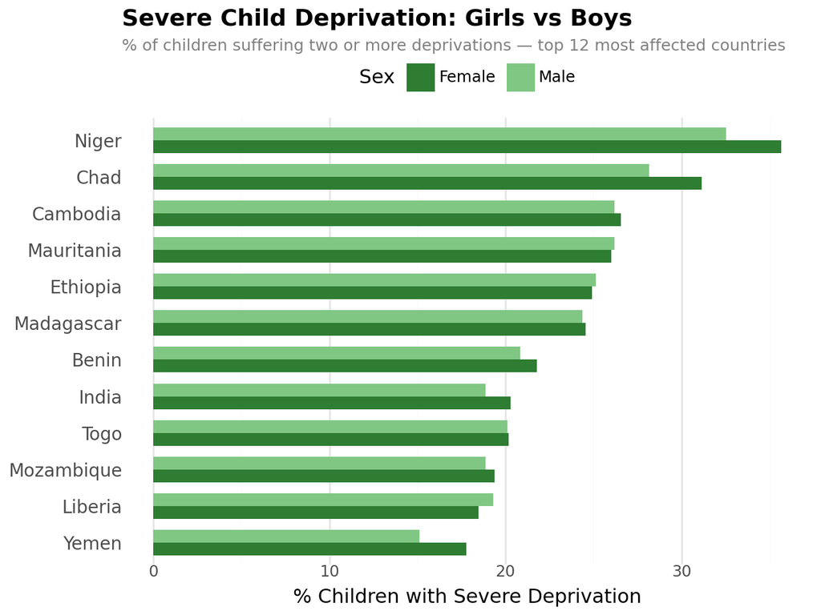

Figure 2: Severe Child Deprivation: Girls vs Boys — top 12 most affected countries

```python
# Select top 12 countries by female deprivation rate
top_countries_dep = (
    deprivation_by_sex
    .filter(pl.col('sex') == 'Female')
    .sort('deprivation_pct', descending=True)
    .head(12)
    .select('country')
)

dep_bar_df = (
    deprivation_by_sex
    .join(top_countries_dep, on='country', how='inner')
    .to_pandas()
)

# Order countries by female deprivation for clean display
female_order = (
    dep_bar_df[dep_bar_df['sex'] == 'Female']
    .sort_values('deprivation_pct', ascending=True)['country'].tolist()
)
dep_bar_df['country'] = dep_bar_df['country'].astype('category').cat.set_categories(female_order)

bar_plot = (
    ggplot(dep_bar_df, aes(x='country', y='deprivation_pct', fill='sex'))
    + geom_col(position='dodge', width=0.7)
    + scale_fill_manual(values={'Female': '#2e7d32', 'Male': '#81c784'}, name='Sex')
    + coord_flip()
    + labs(
        title='Severe Child Deprivation: Girls vs Boys',
        subtitle='% of children suffering two or more deprivations — top 12 most affected countries',
        x='',
        y='% Children with Severe Deprivation'
    )
    + theme_minimal()
    + theme(
        plot_title=element_text(size=13, weight='bold'),
        plot_subtitle=element_text(size=9, color='grey'),
        axis_text_y=element_text(size=10),
        panel_grid_major_y=element_blank(),
        legend_position='top'
    )
)
bar_plot
```

## Clean schools, longer lives

*This is not coincidence.* It is the compound effect of poor health, higher absenteeism, and weaker education outcomes across entire generations.

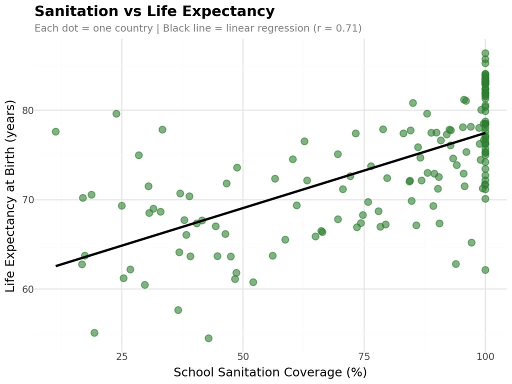

Figure 3: Sanitation vs Life Expectancy — with linear regression line

```python
scatter_df = (
    combined
    .filter(
        pl.col('life_expectancy').is_not_null() &
        pl.col('sanitation_pct').is_not_null()
    )
    .to_pandas()
)

scatter_plot = (
    ggplot(scatter_df, aes(x='sanitation_pct', y='life_expectancy'))
    + geom_point(alpha=0.6, color='#2e7d32', size=3)
    + geom_smooth(method='lm', color='black', se=False, size=1.2)
    + labs(
        title='Sanitation vs Life Expectancy',
        subtitle='Each dot = one country | Black line = linear regression (r = 0.71)',
        x='School Sanitation Coverage (%)',
        y='Life Expectancy at Birth (years)'
    )
    + theme_minimal()
    + theme(
        plot_title=element_text(size=13, weight='bold'),
        plot_subtitle=element_text(size=9, color='grey'),
    )
)
scatter_plot
```

## *A Crisis, 23 Years In The Making*

**The global average dropped 19 points between 2000 and 2013**: population growth outpacing infrastructure. The 2015 SDGs brought renewed focus. But in 2023, coverage is still **14 points below the year 2000**.

Progress exists. But it is *not fast enough*.

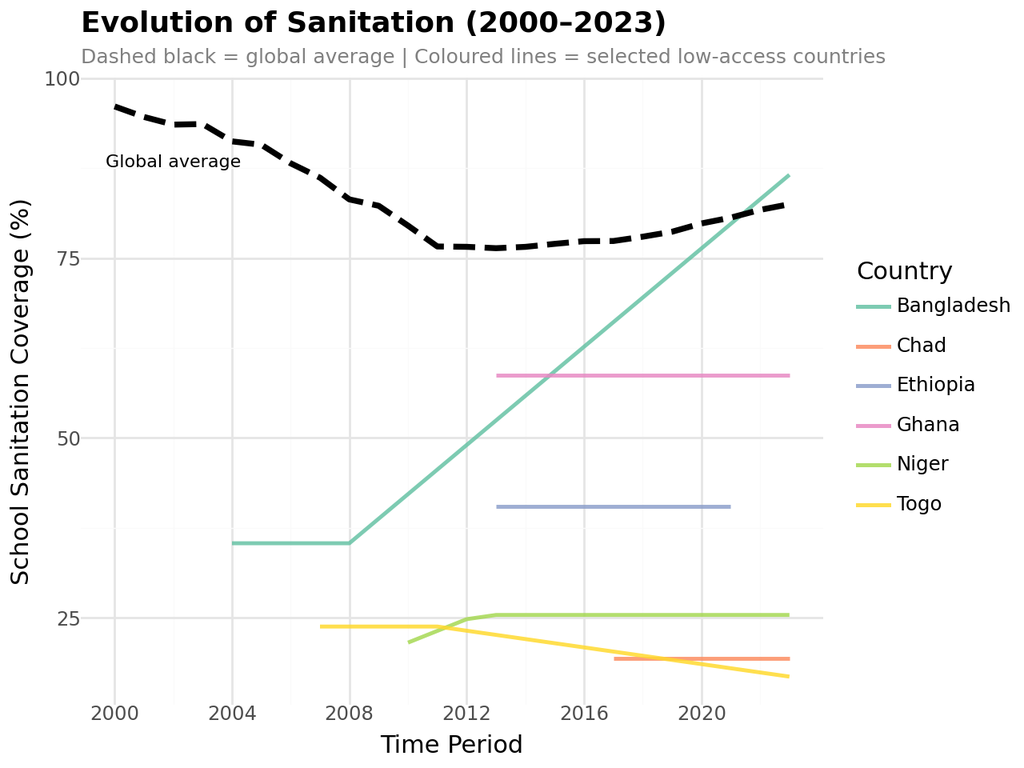

Figure 4: Evolution of school sanitation coverage (2000–2023) — global average and selected countries

```python
global_trend = (
    indicator_2
    .filter(pl.col('sex') == 'Total')
    .group_by('time_period')
    .agg(pl.col('obs_value').mean().alias('avg_sanitation'))
    .sort('time_period')
    .to_pandas()
)
global_trend['country'] = 'Global Average'

focus_countries = ['Chad', 'Niger', 'Togo', 'Ethiopia', 'Ghana', 'Bangladesh']
country_trends = (
    indicator_2
    .filter(
        (pl.col('sex') == 'Total') &
        pl.col('country').is_in(focus_countries)
    )
    .select(['country', 'time_period', 'obs_value'])
    .rename({'obs_value': 'avg_sanitation'})
    .to_pandas()
)

ts_plot = (
    ggplot()
    + geom_line(
        data=country_trends,
        mapping=aes(x='time_period', y='avg_sanitation', color='country'),
        size=1.0, alpha=0.85
    )
    + geom_line(
        data=global_trend,
        mapping=aes(x='time_period', y='avg_sanitation'),
        size=1.5, color='black', linetype='dashed'
    )
    + annotate('text', x=2002, y=global_trend['avg_sanitation'].mean() + 5,
               label='Global average', size=8, color='black')
    + scale_color_brewer(type='qual', palette='Set2', name='Country')
    + scale_x_continuous(breaks=list(range(2000, 2024, 4)))
    + labs(
        title='Evolution of Sanitation (2000–2023)',
        subtitle='Dashed black = global average | Coloured lines = selected low-access countries',
        x='Time Period',
        y='School Sanitation Coverage (%)'
    )
    + theme_minimal()
    + theme(
        plot_title=element_text(size=13, weight='bold'),
        plot_subtitle=element_text(size=9, color='grey'),
        legend_position='right'
    )
)
ts_plot
```

## What happens without sanitation?

The consequences of missing school sanitation fall into four interconnected crises:

- 🚫 **Girls drop out** — Without private facilities, adolescent girls cannot manage menstruation at school — and many simply stay home instead.
- 🦠 **Disease spreads** — No handwashing means preventable illnesses circulate freely. Sick children miss class, fall behind, and eventually leave school.
- 📚 **Learning collapses** — Schools without sanitation see higher absenteeism, lower literacy outcomes, and reduced teacher retention over time.
- 💔 **Dignity denied** — A child who cannot use a safe toilet at school is a child whose basic dignity is not being protected by their society.

## Conclusion

Despite progress, far too many children are still left behind. In 2000, **96.1%** of schools worldwide had basic sanitation. In 2023, that figure stands at **82.5%**. The first and most crucial step is raising awareness. By working together, we can ensure that *every child* (regardless of country, income, or background) **learns in a clean, safe school**.

*By Soukaina Belabbes*  
*Sources: UNICEF, WHO/UNICEF Joint Monitoring Programme (JMP) for Water Supply, Sanitation and Hygiene, 2023*

```python
import os
print(os.listdir('/content'))
```

```
['.config', 'unicef_indicator_1 (2) (1).csv', 'unicef_indicator_2 (2) (1).csv', 'soukaina_belabbes.ipynb', 'unicef_indicator_2 (2) (2).csv', 'unicef_indicator_1 (2).csv', 'unicef_metadata (2).csv', 'unicef_indicator_1 (2) (2).csv', 'unicef_indicator_2 (2).csv', 'unicef_metadata (2) (2).csv', 'unicef…
```

```python
!curl -LO https://quarto.org/download/latest/quarto-linux-amd64.deb
!sudo dpkg -i quarto-linux-amd64.deb
```

[output not shown]

```python
!quarto render /content/soukaina_belabbes.ipynb --to html
```

[output not shown]